# Lesson 9: Inference for One Mean; Sigma Known (Hypothesis Test)

Preparation

- Word Document
- PDF Document

## Solutions

Problem

Part

Solution

1

-

Null hypothesis

2

-

One Side

3

-

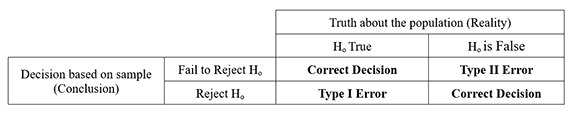

4

-

The level of significance is a number to determine if the P-value is small enough to reject the null hypothesis. It is denoted with the Greek letter alpha ($\alpha$). It is the probability of making a Type I Error.

5

-

$z=\frac{\bar{x}-\mu}{\sigma / \sqrt{n}}$

6

-

P-value is the probability that you will observe the sample test statistic you did or one more extreme assuming the null hypothesis is true.

7

-

We have sufficient evidence to conclude the alternative hypothesis is true.

8

-

Answers may vary

9

A

$H_o: \mu =$ 529  
$H_a: \mu >$ 529

9

B

A Type I error was committed.

9

C

There was about a 1 in 100 or 1% chance that there would be a Type 1 Error.

9

D

Increase the level of significance.

10

Design the study

The researcher collects data from the population of second home buyers. It says that he randomly selects his sample from his own clients. His research question is,‘Is the average age of the people buying a second investment property in my area different than the national average?’

10

Collect the data

(Answers may vary)

10

Describe the data

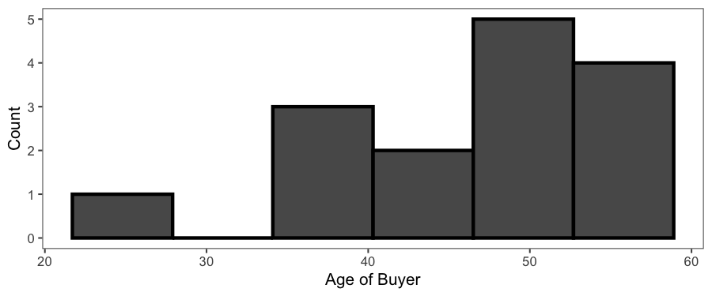

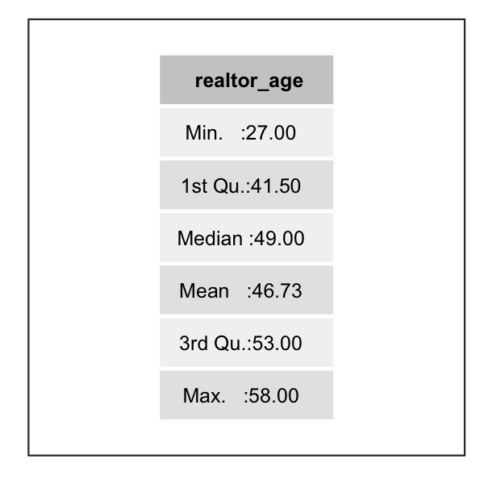

10

Make Inference-I

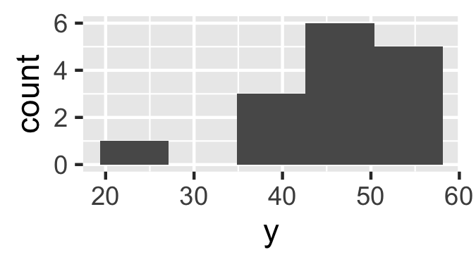

10

Make -Inference II

$H_o: \mu =$ 47 years old  
$H_a: \mu \neq$ 47 years old

10

Make Inference- III

$\alpha=$ 0.05

10

Make Inference-IV

$\frac{\bar{x}-\mu}{\sigma / \sqrt{n}}$; z=-0.207

10

Make Inference-V

P-value = 0.836

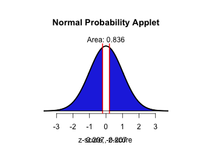

10

Make Inference-VI

P-value is > level of significance ; 0.836 > 0.05 so we fail to reject the null hypothesis

10

Make Inference-VII

We have insufficient evidence to conclude that the mean age of people buying a second home is different in this area, than that of the national average of 47 .

10

Take Action

(Answers may vary) One could would suggest that the realtor keeps targeting that population of middle aged people as second home buyers.